# Stat 579 - A dispute - An attempt at a solution

Heike Hofmann

# A ‘Solution’ to the test case

## A Plan of work

0. Find out where the data comes from
1. Describe the working environment
2. Verify that there is a variable for weight in the data and read the description of the variables in the codebook.
3. Calculate average for weight, then report.
4. Write a short report of your findings. Address potential problems in the data.

# A solution attempt

0. Setup
   - this solution uses R v4.3.2 in RStudio (2023.06.2 Build 561).
   - You need the R packages `tidyverse` and `rmarkdown` to run the solution
   - use the command `install.packages(c("tidyverse","rmarkdown"))` in the R console to install the two packages
1. Navigate to https://github.com/Stat579-at-ISU/materials-2023
2. Download the file [`test-case-solution.Rmd`](https://raw.githubusercontent.com/Stat579-at-ISU/materials-2023/master/01_collaborative-environment/test-case-solution.Rmd) in folder `01_collaborative-environment` in RStudio to get this set of slides.
3. “Knit” the file (Click on the button in the menu).

## The Data Source

The dataset `brfss_iowa.csv` (linked from website) contains 6227 records from the Behavioral Risk Factor Surveillance System (BRFSS) for Iowans.

> The Behavioral Risk Factor Surveillance System (BRFSS) is the nation’s premier system of health-related telephone surveys that collect state data about U.S. residents regarding their health-related risk behaviors.

It is conducted annually by the Center for Disease Control and Prevention (CDC).

Codebook with detailed explanations of variables is [available here](https://www.cdc.gov/brfss/annual_data/2015/pdf/codebook15_llcp.pdf).

## What is Iowan’s average weigth in 2015?

Read the data:

```r
library(tidyverse)
iowa <- readr::read_csv("https://github.com/Stat579-at-ISU/materials/raw/master/01_collaborative-environment/data/brfss_iowa.csv")
# the read_csv function from the readr package is faster than the standard read.csv
# but the output is a tibble (we'll come back to that)

iowa
```

```
## # A tibble: 6,227 × 330
##    X_STATE FMONTH IDATE    IMONTH IDAY  IYEAR DISPCODE     SEQNO  X_PSU CTELENUM
##      <dbl>  <dbl> <chr>    <chr>  <chr> <dbl>    <dbl>     <dbl>  <dbl>    <dbl>
##  1      19      7 07082015 07     08     2015     1200    2.02e9 2.02e9       NA
##  2      19      3 03212015 03     21     2015     1200    2.02e9 2.02e9       NA
##  3      19     10 01102016 01     10     2016     1200    2.02e9 2.02e9       NA
##  4      19      4 05092015 05     09     2015     1200    2.02e9 2.02e9       NA
##  5      19      5 06242015 06     24     2015     1200    2.02e9 2.02e9       NA
##  6      19      7 08032015 08     03     2015     1200    2.02e9 2.02e9       NA
##  7      19      7 08122015 08     12     2015     1200    2.02e9 2.02e9       NA
##  8      19      7 08102015 08     10     2015     1200    2.02e9 2.02e9       NA
##  9      19     10 11152015 11     15     2015     1200    2.02e9 2.02e9       NA
## 10      19      8 08132015 08     13     2015     1200    2.02e9 2.02e9       NA
## # ℹ 6,217 more rows
## # ℹ 320 more variables: PVTRESD1 <dbl>, COLGHOUS <lgl>, STATERES <dbl>,
## #   CELLFON3 <dbl>, LADULT <lgl>, NUMADULT <dbl>, NUMMEN <dbl>, NUMWOMEN <dbl>,
## #   CTELNUM1 <dbl>, CELLFON2 <dbl>, CADULT <dbl>, PVTRESD2 <dbl>,
## #   CCLGHOUS <dbl>, CSTATE <dbl>, LANDLINE <dbl>, HHADULT <dbl>, GENHLTH <dbl>,
## #   PHYSHLTH <dbl>, MENTHLTH <dbl>, POORHLTH <dbl>, HLTHPLN1 <dbl>,
## #   PERSDOC2 <dbl>, MEDCOST <dbl>, CHECKUP1 <dbl>, BPHIGH4 <dbl>, …
```

## Variables for weight

```r
grep("WEIGHT", names(iowa), value=TRUE)
```

```
## [1] "WEIGHT2"
```

```r
iowa %>% select(WEIGHT2) %>% head()
```

```
## # A tibble: 6 × 1
##   WEIGHT2
##     <dbl>
## 1     191
## 2     140
## 3     135
## 4     115
## 5      NA
## 6     210
```

Variable is there … let’s plot it …

## Plot

Load the `ggplot2` package to plot weight:

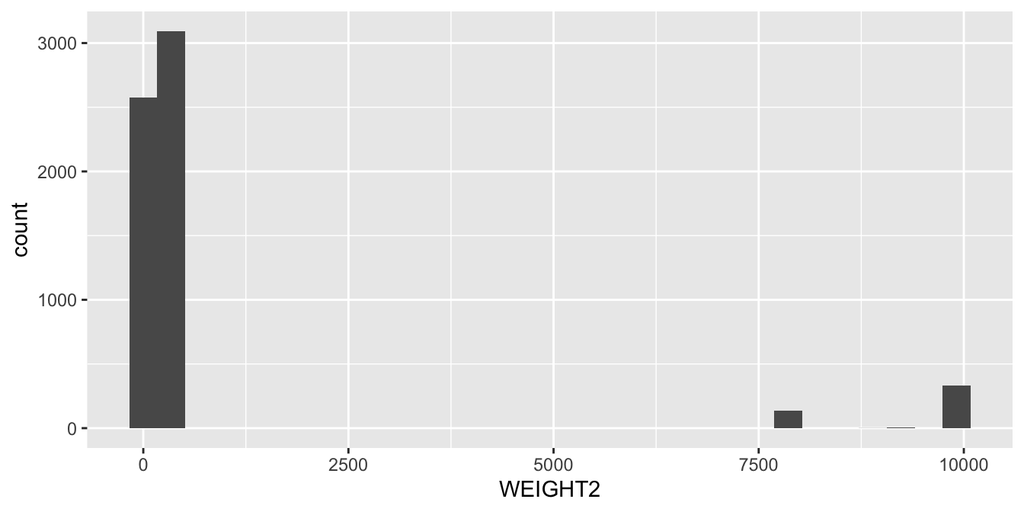

```r
iowa %>%
  ggplot(aes(x = WEIGHT2)) + geom_histogram()
```

There are some very odd values. Check the codebook.

## Codebook excerpt

From the [codebook](https://www.cdc.gov/brfss/annual_data/2015/pdf/codebook15_llcp.pdf): WEIGHT2 is the originally recorded variables.

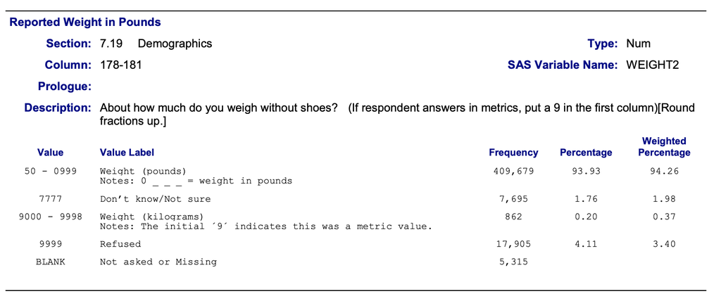

–

Values are a mix of metric and empirial values, refusals are coded as 9999 and don’t know’s as 7777.

## Next steps

Obviously, we need to spend some time cleaning these variables before we can make use of them.

We have a couple of choices :

1. We can buckle down and do that clean-up and then move on to the calculation.
2. We can take another look at the variables and investigate `WTKG3` are …

## Route 2

Let’s take the second route first and draw a picture weight in metric units:

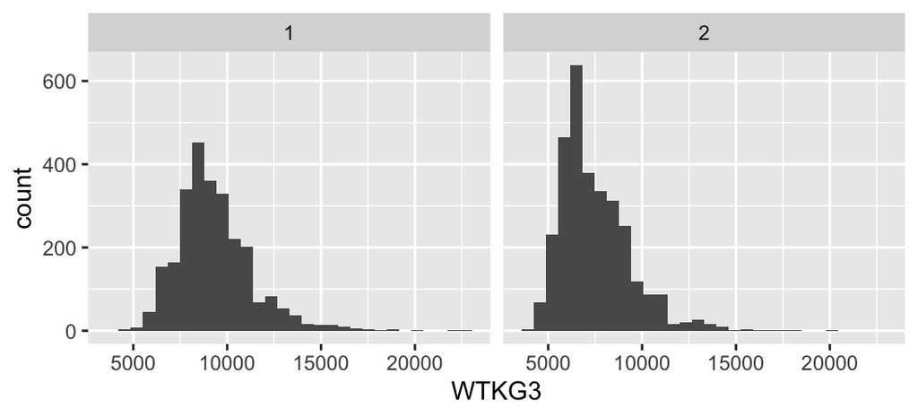

```r
iowa %>%
  ggplot(aes(x = WTKG3)) + geom_histogram() +
  facet_grid(.~SEX)
```

These values look much better! But the weight is reported in tens of grams (???)

## Look at the variable’s values

Based on variable `WTKG3`

```r
summary(iowa$WTKG3) # divide by 100 for kg
```

```
##    Min. 1st Qu.  Median    Mean 3rd Qu.    Max.    NA's
##    3856    6804    8119    8319    9525   22680     552
```

```r
summary(iowa$WTKG3/45.4) # in pounds
```

```
##    Min. 1st Qu.  Median    Mean 3rd Qu.    Max.    NA's
##   84.93  149.87  178.83  183.24  209.80  499.56     552
```

–

This was solution number 3: 83.2 kg (or 183 lbs)

## How did we get the other values?

Based on variable `WEIGHT2`

```r
summary(iowa$WEIGHT2) # don't do this!!!
```

```
##    Min. 1st Qu.  Median    Mean 3rd Qu.    Max.    NA's
##    85.0   150.0   180.0   894.3   220.0  9999.0      84
```

The median was used for solution #2 of 180 lbs.

```r
iowa %>% filter(WEIGHT2 < 7777) %>% select(WEIGHT2) %>%
  summarize(n = n(), mean_lbs = mean(WEIGHT2), mean_kgs = mean(WEIGHT2*.454))
```

```
## # A tibble: 1 × 3
##       n mean_lbs mean_kgs
##   <int>    <dbl>    <dbl>
## 1  5667     183.     83.3
```

```r
# number of metric responses:
filter(iowa, between(WEIGHT2, 9001, 9500)) %>% nrow()
```

```
## [1] 8
```

## Route 1

This is quite a bit more work. Don’t do things this way!

```r
# first of all, replace all missing values by NAs
iowa <- iowa %>% mutate(
  WEIGHT2 = replace(WEIGHT2, WEIGHT2 %in% c(7777,9999), NA)
)
```

## Route 1 (cont’d.)

1 pound is 0.454 kg: convert to metric:

```r
iowa <- iowa %>% mutate(
  weight = ifelse(WEIGHT2 >= 9000,
                  WEIGHT2 - 9000, # transform all metric values by subtracting 9000
                  WEIGHT2*.454 # 1 lbs = 0.454 kg
                  )
)
```

## Route 1

```r
iowa %>%
  select(WEIGHT2, WTKG3, weight) %>% summary()
```

```
##     WEIGHT2           WTKG3           weight
##  Min.   :  85.0   Min.   : 3856   Min.   : 38.59
##  1st Qu.: 150.0   1st Qu.: 6804   1st Qu.: 68.10
##  Median : 179.0   Median : 8119   Median : 81.27
##  Mean   : 195.9   Mean   : 8319   Mean   : 83.27
##  3rd Qu.: 210.0   3rd Qu.: 9525   3rd Qu.: 95.34
##  Max.   :9145.0   Max.   :22680   Max.   :227.00
##  NA's   :552      NA's   :552     NA's   :552
```

## Recap

- this slide deck is rendered from an R Markdown document, located at [a github repo](https://github.com/Stat579-at-ISU/materials-2023/tree/master/01_collaborative-environment).
- code and text/documentation are interwoven: reproducible and self-documenting.
- extend or refine analyses by copying and modifying code blocks.
- disseminate your work by sharing the RMarkdown file